# Methods/Results

# Methods

## Population

We present a spatial explicit stochastic agent based model that recreates the day to day dynamics in a typical nursery home during the COVID pandemic in the United States. We use an hourly time step resolution and we ran the model for 150 days.

### Population structure

We used the floor plans and satellite imagery to recreate the spatial structure of a typical nursery home in the US (figure 1). The nursery home consist on 58 bedrooms designated for the residents, recreation areas (such as dining room, and activities rooms), and rooms for staff use. In the initial conditions there are 3 residents per room (total 174) and 170 staff divided into 3 different turns. The decision on the population distribution was based on information obtained from an interview with a nursery home in California.

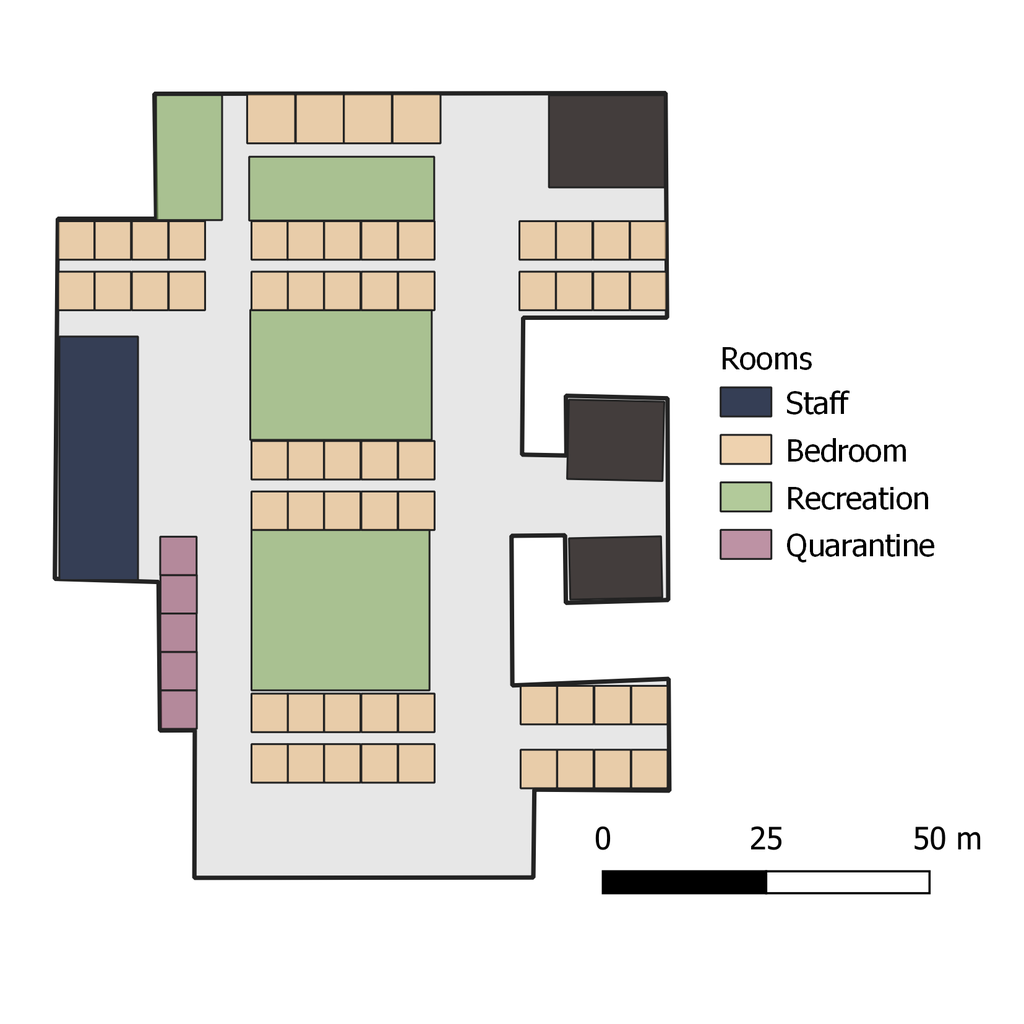